# Exercise 2

Alexandra Anderson

2023-09-13

# **A Look at *Heloderma* Morphometrics**

Who Will Win?

[video not shown]

This webpage highlights some preliminary analysis done on Gila monster morphometrics comparing body proportions of males and females of the species. This comparison aims to investigate different facets of sexual selection that may exist in this species.

[figure not shown]

A male and female Gila monster side by side

# A Brief Summary of the Data Collected

This data has a total of 127 measured specimens. The average SVL is 261.03 millimeters. SVLs range from 120 to 389 millimeters

# Looking at the Belly of the Beast

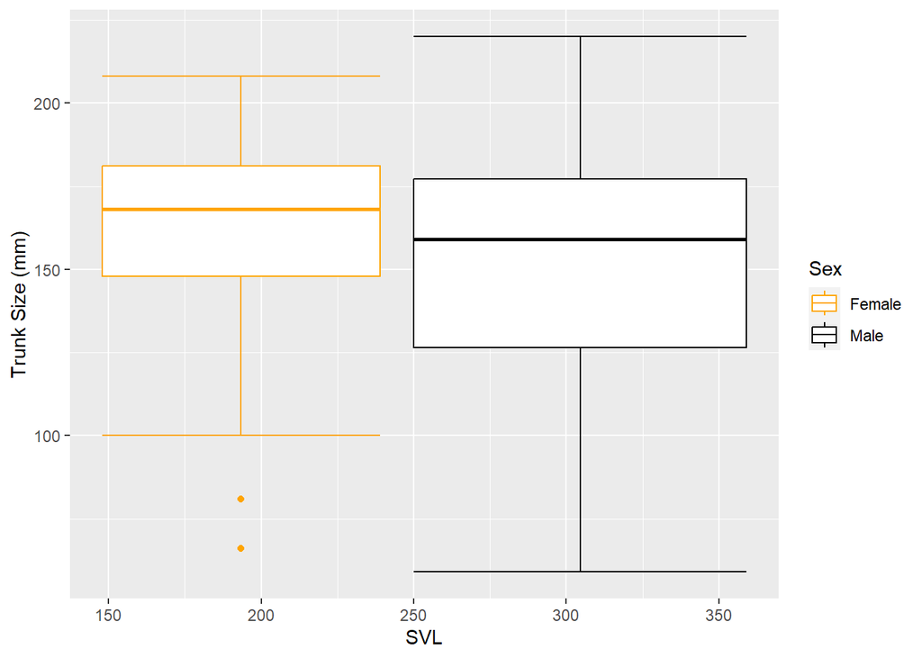

This data summary serves to show the mean trunk size for each sex.

```
## # A tibble: 2 × 2
##   Sex    meantrunk
##   <chr>      <dbl>
## 1 Female      161.
## 2 Male        147.
```

This is a scatterplot highlighting the allometric relationship between SVL and trunk size in *Heloderma*.

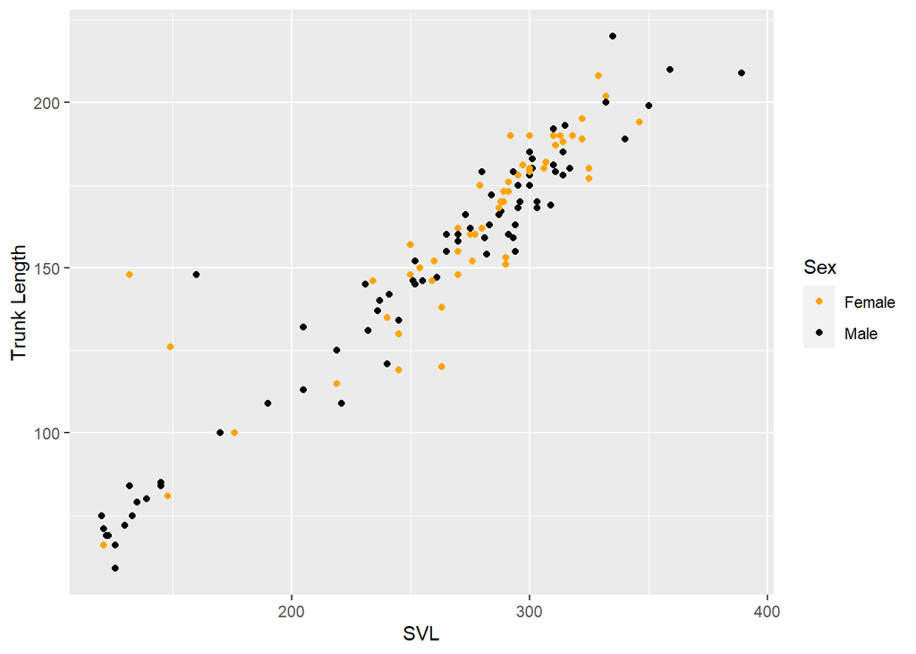

This linear model looks at the relationship between SVL and trunk

```
## Analysis of Variance Table
##
## Response: trunk
##            Df Sum Sq Mean Sq F value    Pr(>F)
## SVL         1 154997  154997  1013.6 < 2.2e-16 ***
## Residuals 125  19114     153
## ---
## Signif. codes:  0 '***' 0.001 '**' 0.01 '*' 0.05 '.' 0.1 ' ' 1
```

This is a ktable highlighting the difference in trunk sizes between *Heloderma suspectum* and *Heloderma horridum.*

Table 2. A summary kable displaying number, mean, and standard deviation for the trunk lengths of each species.

| Species | n | mean | sd |
| --- | --- | --- | --- |
| horridum | 5 | 173.6 | 46.8 |
| suspectum | 122 | 151.9 | 36.7 |

# Trying Not to Get a Big Head About it

This linear model looks at the relationship between Headwidth and SVL.

```
## Analysis of Variance Table
##
## Response: HW
##            Df Sum Sq Mean Sq F value    Pr(>F)
## SVL         1 7450.0  7450.0  190.73 < 2.2e-16 ***
## Residuals 125 4882.6    39.1
## ---
## Signif. codes:  0 '***' 0.001 '**' 0.01 '*' 0.05 '.' 0.1 ' ' 1
```

Here is another scatter plot, looking at the relationship between head width and body size!

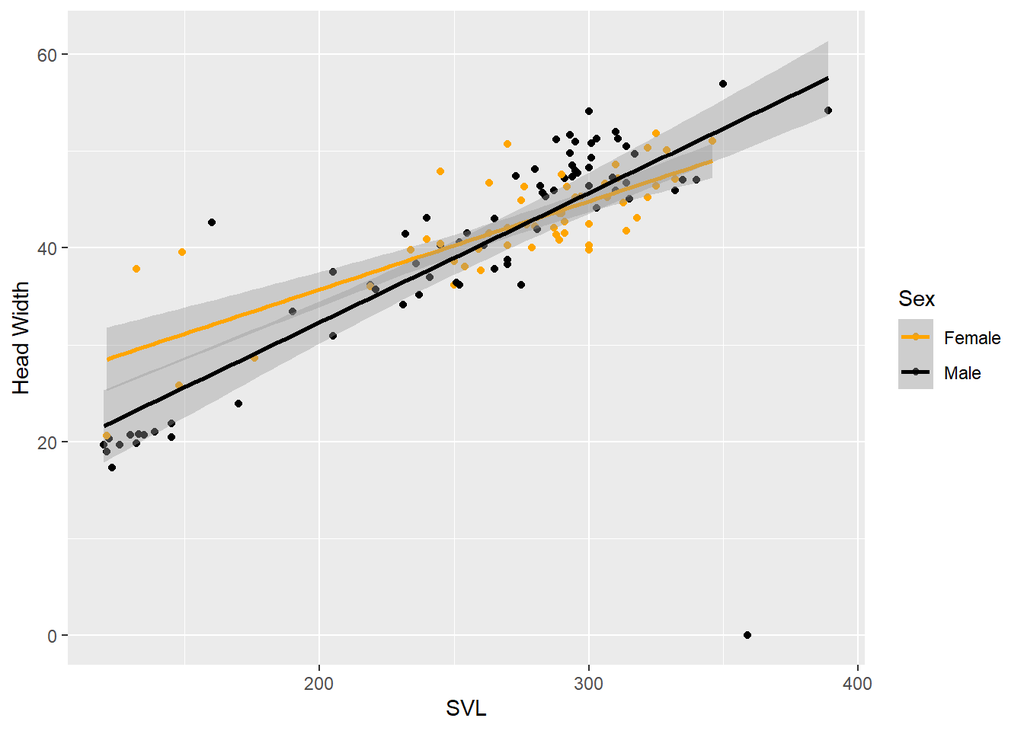

# Some Extra Bits

This ktable is showing the first 10 lines of the *Heloderma* data frame.

Table 1. A kable displaying the first 10 Heloderma in the data set.

| Source | Catalog_Num | Lizard_ID | Species | Sex | Collection_Date | collector | Locality | Collection_Notes | Dissection_Notes | Country | State | elevation | County | spatial_accuracy | georef_verif | SVL | insert_elbow | Tail | elbow_wrist | Tail_Diam | wrist_3rd | HL | trunk | HW | HL_ear_rostral |
| --- | --- | --- | --- | --- | --- | --- | --- | --- | --- | --- | --- | --- | --- | --- | --- | --- | --- | --- | --- | --- | --- | --- | --- | --- | --- |
| ASU | 194 | ASU194 | suspectum | Male | 12/28/1953 | H.H. ROWLEYS | ROOSEVELT LAKE | IN CHURN |  | USA | Arizona | 673 | Gila | 20 | Yes | 314 | 20.9 | 0 | 22.9 | 29.3 | 29.6 | 54.5 | 178 | 46.7 | 61.9 |
| ASU | 195 | ASU195 | suspectum | Female | 6/3/1954 | R. LATTIMORE | SE OF APACHE | IN CHURN | rt ovid = 4 bb sized follicles | USA | Arizona | NA | Maricopa | NA | ref not possible | 285 | 20.6 | 130 | 23.9 | 23.0 | 29.6 | 46.4 | 160 | 44.3 | 54.0 |
| ASU | 196 | ASU196 | suspectum | Female | 4/29/1953 | R. PRESTON | BETWEEN FLORENCE AND QUEEN CREEK | IN CHURN |  | USA | Arizona | 461 | Maricopa | 20 | Yes | 314 | 17.9 | 145 | 21.8 | 22.1 | 29.9 | 52.2 | 188 | 41.8 | 56.3 |
| ASU | 197 | ASU197 | suspectum | Male | 8/7/1955 |  | SCOTTSDALE | IN CHURN | testes barely visible | USA | Arizona | 417 | Maricopa | 10 | Yes | 133 | 8.3 | 58 | 9.8 | 10.6 | 14.5 | 23.7 | 75 | 20.8 | 25.6 |
| ASU | 706 | ASU706 | suspectum | Female | 4/17/1956 |  | CAMELBACK MT., SCOTTSDALE | IN CHURN | lt ovid = 11.4, 10.1, 3peas; rt ovid = 6.3, 9.0, 11.8, and 2 peas | USA | Arizona | 767 | Maricopa | 5 | Yes | 279 | 18.1 | 129 | 23.2 | 24.1 | 29.7 | 46.3 | 175 | 40.0 | 51.0 |
| ASU | 908 | ASU908 | suspectum | Male | 4/5/1955 |  | BUCKEYE | IN CHURN | hemipenes everted | USA | Arizona | 435 | Maricopa | 10 | Yes | 283 | 19.4 | 158 | 25.8 | 29.3 | 29.5 | 49.6 | 163 | 45.7 | 53.0 |
| ASU | 910 | ASU910 | suspectum | Female | 8/26/1955 |  | CASA GRANDE | IN CHURN | 3 full term eggs (pics), 36.8, 34.9, 33.2 | USA | Arizona | 424 | Pinal | 5 | Yes | 311 | 19.8 | 135 | 29.6 | 29.0 | 32.4 | 50.6 | 187 | 47.2 | 56.9 |
| ASU | 911 | ASU911 | suspectum | Male | 9/11/1955 |  | SAGUARO LAKE | IN CHURN | hemipene everted; rt teste = 10.0, lt teste = 8.8 | USA | Arizona | 551 | Maricopa | 10 | Yes | 296 | 20.6 | 145 | 24.0 | 27.5 | 28.9 | 47.9 | 170 | 47.7 | 56.3 |
| ASU | 912 | ASU912 | suspectum | Female | 11/2/1955 | W. MCLARSINGH | CHANDLER | IN CHURN | oviducts | USA | Arizona | 368 | Maricopa | 10 | Yes | 291 | 21.3 | 133 | 25.5 | 26.7 | 29.2 | 41.5 | 173 | 42.7 | 49.3 |
| ASU | 918 | ASU918 | suspectum | Female | 6/22/1955 |  | CHRISTMAS | IN CHURN (CMG; no Christmas in Pinal County, only in Gila County, just over border) | both oviducts empty | USA | Arizona | 799 | Gila | 5 | Yes | 277 | 16.5 | 137 | 23.2 | 26.2 | 28.7 | 45.5 | 160 | 42.4 | 52.9 |

A Map featuring the zoological museum at Arizona State University, where some of the data used in this analysis was collected.

[interactive chart not shown]

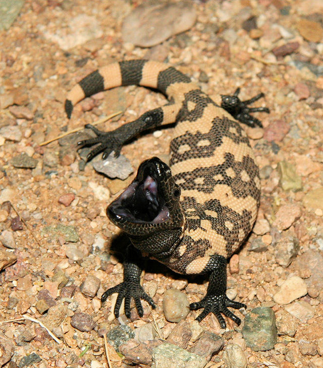

Thanks for Visiting!